# Faith Liz’s Final Portfolio

- Show All Code
- Hide All Code
- View Source

```python
import altair as alt
import pandas as pd
```

### Exercise 1

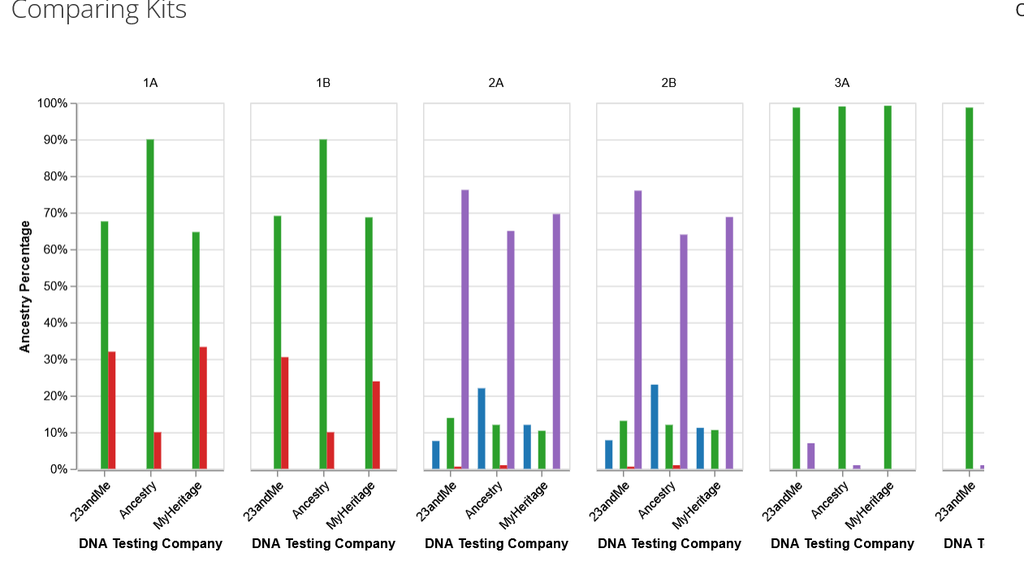

2. I disliked graphic 7b in the gallery.I did not like was the scatter plot with many small points representing different twin groups and kits. The chart felt cluttered and difficult to interpret because there were too many overlapping details and not enough structure. It was hard to quickly understand patterns or make comparisons. Generally, the graph had too much going for it.

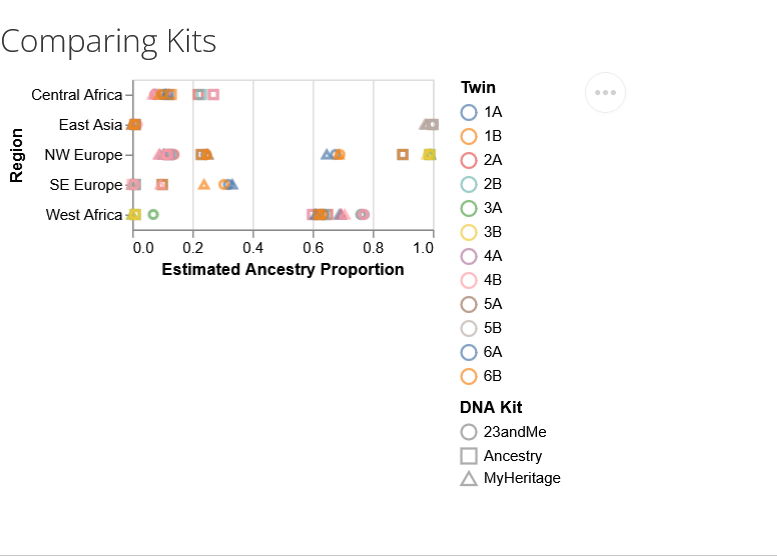

c.i.

```python
df = pd.read_csv('twins-genetics-long.csv')

chart1 = alt.Chart(df).mark_bar().encode(
    x=alt.X('kit:N'),
    y=alt.Y('genetic share:Q', title='Genetic Share (%)'),
    color=alt.Color('kit:N', legend=None),
    column=alt.Column('region:N',
                      title='Ancestry Region',
                      header=alt.Header(labelAngle=-45))
).properties(
    title='How Genetic Ancestry Estimates Differ Across Testing Kits'
).resolve_scale(
    y='independent'
)

chart1
```

[interactive chart not shown]

This visualization compares how different genetic testing kits estimate ancestry composition across regions.By faceting the chart by region, it becomes easier to focus on one ancestry category at a time and compare how each company reports genetic share. The visualization reveals that while general trends are consistent, the exact percentages vary across kits, highlighting differences in estimation methods.

```python
# Dropdown selection for pair
pair_select = alt.selection_point(fields=['pair'], bind=alt.binding_select(options=sorted(df['pair'].unique()), name="Select Pair:"))

base = alt.Chart(df).add_params(pair_select).transform_filter(pair_select)

bars = base.mark_bar().encode(
    x=alt.X('region:N', sort='-y', title='Region'),
    y=alt.Y('genetic share:Q', title='Genetic Share'),
    color=alt.Color('twin:N', title='Twin'),
    tooltip=['twin', 'region', 'genetic share', 'kit']
)



chart2 = bars.properties(
  width = 450,
  height = 300,
    title='Detailed Comparison of Genetic Similarity Between Twins (Interactive)'
)


chart2
```

[interactive chart not shown]

### Exercise 2

Issues:misleading y‑axis, overly thin bars, cluttered annotations, and a title that mixed interpretation with description.

Improvement: redesigned the visualization using a stacked bar chart with a clean monthly time axis and simplified labeling. I removed distracting annotations and replaced them with tooltips, which provide detail on demand without cluttering the view.

```python
points = pd.read_csv("touchpoints.csv")

# Melt into long format
points_long = points.melt(
    id_vars='Date',
    value_vars=['Phone Touchpoints', 'Chat Touchpoints', 'Email Touchpoints'],
    var_name='Channel',
    value_name='Touchpoints'
)

colors = alt.Scale(
    domain=['Phone Touchpoints', 'Chat Touchpoints', 'Email Touchpoints'],
    range=['#1f77b4', '#ff7f0e', '#17becf']   # blue, orange, teal
)


chart = alt.Chart(points_long).mark_bar(size=12).encode(
    x=alt.X('yearmonth(Date):T', title='Month'),
    y=alt.Y('Touchpoints:Q', title='Touchpoints'),
    color=alt.Color('Channel:N', scale=colors, title='Channel'),
    tooltip=['Date:T', 'Channel:N', 'Touchpoints:Q']
).properties(
    width=650,
    height=350,
    title='Total Touchpoints Over Time'
).configure_axis(
    grid=False,
    labelFontSize=12,
    titleFontSize=14
).configure_title(
    fontSize=18,
    anchor='start',
    fontWeight='bold'
).configure_legend(
    labelFontSize=12,
    titleFontSize=13
)

chart
```

[interactive chart not shown]

### Exercise 3

```python
df = pd.read_csv("Tanzania.csv")

# Clean column names
df.columns = df.columns.str.strip()

# Clean Survey_year
df["Survey_year"] = df["Survey_year"].astype(str).str.strip()

# Compute midpoint
def midpoint(year_str):
    if "-" in year_str:
        a, b = year_str.split("-")
        return (int(a) + int(b)) / 2
    else:
        return int(year_str)

df["year"] = df["Survey_year"].apply(midpoint)

# Line for Total Fertility Rate
tfr_line = (
    alt.Chart(df)
    .mark_line(point=True, color="#1f77b4")
    .encode(
        x="year:Q",
        y="Total_fertility_rate:Q",
        tooltip=["Survey_year", "Total_fertility_rate"]
    )
)

# Line for Unmet Need
unmet_line = (
    alt.Chart(df)
    .mark_line(point=True, color="#d62728")
    .encode(
        x="year:Q",
        y="Unmet_need:Q",
        tooltip=["Survey_year", "Unmet_need"]
    )
)

chart = (tfr_line + unmet_line).properties(
    width=500,
    height=300,
    title="Tanzania: Total Fertility Rate and Unmet Need for Family Planning"
)

chart
```

[interactive chart not shown]

Tanzania has experienced a steady decline in fertility over the past 25 years, while unmet need for family planning has remained persistently high.

This combination shows that although women are having fewer children, access to or use of contraception has not kept pace with women’s reproductive intentions.

### Exercise 4

I created a slopegraph comparing the gender wage gap between 2005 and 2024 across OECD countries, highlighting the Nordic countries (Denmark, Finland, Iceland, Norway, and Sweden). These countries are widely recognized for gender equality, and highlighting them allows the viewer to immediately see how their wage gaps compare to global patterns. The dataset is from https://www.oecd.org/en/data/indicators/gender-wage-gap.html.

```python
# Load your dataset
df = pd.read_csv("wagegap.csv")
df.columns = df.columns.str.strip()

# Keep only needed columns
df = df[["Reference area", "TIME_PERIOD", "OBS_VALUE"]]

# Convert year to numeric
df["TIME_PERIOD"] = pd.to_numeric(df["TIME_PERIOD"], errors="coerce")

# Filter for the two comparison years
years_to_use = [2005, 2024]
df_filtered = df[df["TIME_PERIOD"].isin(years_to_use)].dropna(subset=["OBS_VALUE"])


df_filtered = (
    df_filtered
    .groupby(["Reference area", "TIME_PERIOD"], as_index=False)["OBS_VALUE"]
    .mean()
)

# Nordic countries
nordics = ["Denmark", "Finland", "Iceland", "Norway", "Sweden"]
df_filtered["highlight"] = df_filtered["Reference area"].isin(nordics)

# Compute change for sorting
pivot = df_filtered.pivot(index="Reference area", columns="TIME_PERIOD", values="OBS_VALUE")
pivot["change"] = pivot[2024] - pivot[2005]
sorted_countries = pivot.sort_values("change")["change"].index.tolist()

# Base chart
base = alt.Chart(df_filtered).encode(
    x=alt.X("TIME_PERIOD:O", title="Year"),
    y=alt.Y("Reference area:N", sort=sorted_countries, title=""),
    detail="Reference area:N"
)

# Lines
lines = base.mark_line().encode(
    color=alt.condition(
        alt.datum.highlight,
        alt.value("#d62728"),
        alt.value("#cccccc")
    ),
    size=alt.condition(
        alt.datum.highlight,
        alt.value(3),
        alt.value(1)
    )
)

# Points
points = base.mark_circle(size=80).encode(
    color=alt.condition(
        alt.datum.highlight,
        alt.value("#d62728"),
        alt.value("#999999")
    )
)

# Labels for 2024
labels_2024 = base.mark_text(align="left", dx=6).encode(
    text=alt.Text("OBS_VALUE:Q", format=".1f"),
    color=alt.condition(
        alt.datum.highlight,
        alt.value("#d62728"),
        alt.value("#555555")
    )
).transform_filter(
    alt.datum.TIME_PERIOD == 2024
)

# Labels for 2005
labels_2005 = base.mark_text(align="right", dx=-6).encode(
    text=alt.Text("OBS_VALUE:Q", format=".1f"),
    color=alt.condition(
        alt.datum.highlight,
        alt.value("#d62728"),
        alt.value("#555555")
    )
).transform_filter(
    alt.datum.TIME_PERIOD == 2005
)

# Combine
chart = (lines + points + labels_2005 + labels_2024).properties(
    width=600,
    height=900,
    title="Gender Wage Gap (2005 vs 2024) — Highlighting Nordic Countries"
)

chart
```

[interactive chart not shown]

For this graphic, I chose a slopegraph to compare the gender wage gap across OECD countries between 2005 and 2024. A slopegraph is especially effective for showing change between two points in time because it uses minimal ink while maximizing clarity. I highlighted the Nordic countries (Denmark, Finland, Iceland, Norway, and Sweden) because they are internationally recognized for strong gender‑equality policies, and emphasizing them allows the viewer to quickly see how their wage‑gap trajectories compare to the broader OECD pattern.I made the Nordic countries in a bold red while keeping all other countries in muted gray. This contrast directs attention without overwhelming the viewer.I sorted countries by the magnitude of change rather than alphabetically. This ordering creates a more meaningful narrative i.e countries with the largest reductions appear at one end of the chart, while those with smaller improvements or increases appear at the other.

A time‑series chart would have shown more years, but it quickly became cluttered and made it difficult to focus on the specific before‑and‑after comparison required for this assignment.

A grouped bar chart was an option, but it introduced too much and made it harder to compare changes directly.

### Exercise 5

My twins graphic uses an interactive dropdown menu.

### Exercise 6

I used a slope graph, it is a combination of differenet marks i.e line, points. Using alt.condition() for styling

2. Wilke stresses the importance of using color intentionally and sparingly in Chapter 4.

Tufte emphasizes that good graphics allow the viewer to see many ideas in the shortest time with the least ink in chapter 1 - graphic excellence